# Master en Big Data. Fundamentos Matemáticos del Análisis de Datos (FMAD).

Tarea 2

Julián García Ruiz

24/9/2021

```r
library(dplyr)
library(tinytex) # Crear PDF con Latex
library(kableExtra)
library(tidyverse)
library(haven) # Importar datos
library(ggplot2)
```

# Ejercicio 1. Simulando variables aleatorias discretas.

**Apartado 1:** La variable aleatoria discreta $X1$ tiene esta tabla de densidad de probabilidad (es la variable que se usa como ejemplo en la Sesión ):
$$\begin{array}{|c|c|c|c|c|c|c|}
\hline
\text{valor de }X1 & 0 & 1 & 2 & 3 \\
\hline
\text{Probabilidad de ese valor }P(X = x_i) & \dfrac{64}{125} &
\dfrac{48}{125}& \dfrac{12}{125} & \dfrac{1}{125}\rule{0mm}{6mm} \\[3mm]
\hline
\end{array}$$

Calcula la media y la varianza teóricas de esta variable.

```r
# Creo los vectores de valor de X1 con sus probabilidades

x1 <- c(0, 1, 2, 3)
p1 <- c(64/125, 48/125, 12/125, 1/125)

media_x1 <- sum(x1*p1)
varianza_x1 <- sum(((x1 - media_x1)^2)*p1)

cat("Media:", media_x1)
```

```
## Media: 0.6
```

```r
cat("Varianza:", varianza_x1)
```

```
## Varianza: 0.48
```

**Apartado 2:** Combina `sample` con `replicate` para simular cien mil muestras de tamaño 10 de esta variable $X1$. Estudia la distribución de las medias muestrales como hemos hecho en ejemplos previos, ilustrando con gráficas la distribución de esas medias muestrales. Cambia después el tamaño de la muestra a 30 y repite el análisis.

Lo primero que haremos para una muestra de tamaño 10.

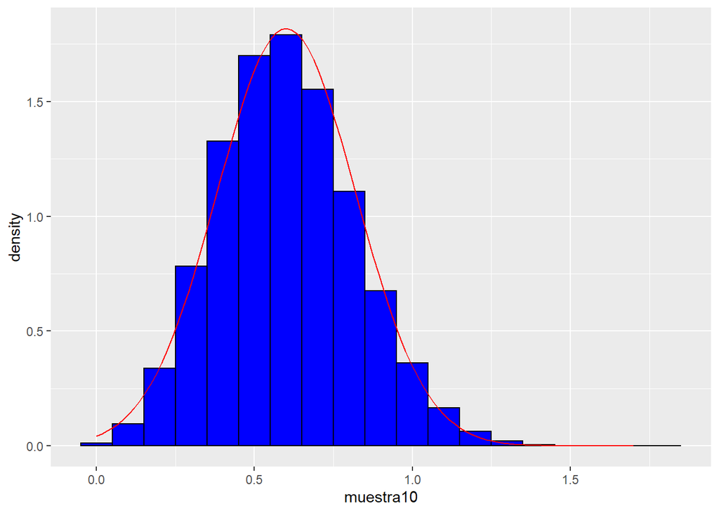

```r
muestra10 <- replicate(100000, {
  x = sample(0:3, size = 10, replace = TRUE, prob = c(64/125, 48/125, 12/125, 1/125))
  mean(x)
})

muestra10 <- as.data.frame(muestra10) # Lo convertimos a un data frame para poder usar ggplot

grafica10 <- ggplot(muestra10) +
  geom_histogram(aes(x = muestra10, y = ..density..),
                 binwidth = 0.1, fill = "blue", color = "black")

x <- seq(0, 1.7, length.out=100)
df <- with(muestra10, data.frame(x = x, y = dnorm(x, mean(muestra10), sd(muestra10))))

grafica10 + geom_line(data = df, aes(x = x, y = y), color = "red")
```

Ahora se hará la de tamaño 30.

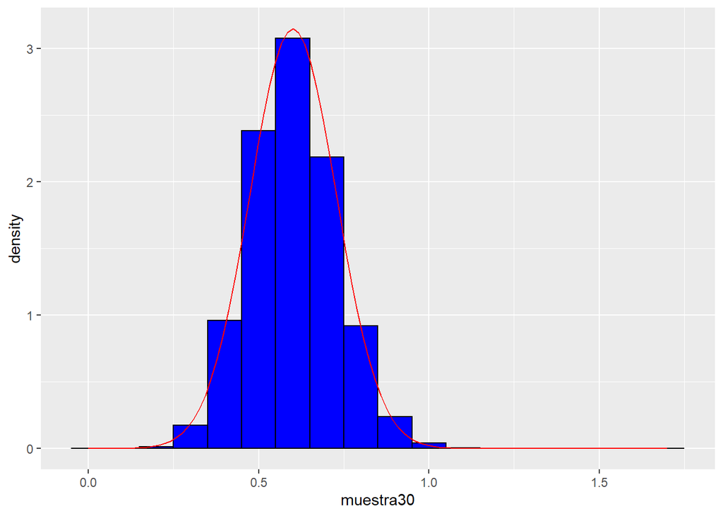

```r
muestra30 <- replicate(100000, {
  x = sample(0:3, size = 30, replace = TRUE, prob = c(64/125, 48/125, 12/125, 1/125))
  mean(x)
})

muestra30 <- as.data.frame(muestra30) # Lo convertimos a un data frame para poder usar ggplot

grafica30 <- ggplot(muestra30) +
  geom_histogram(aes(x = muestra30, y = ..density..),
                 binwidth = 0.1, fill = "blue", color = "black")

x <- seq(0, 1.7, length.out=100)
df <- with(muestra30, data.frame(x = x, y = dnorm(x, mean(muestra30), sd(muestra30))))

grafica30 + geom_line(data = df, aes(x = x, y = y), color = "red")
```

**Apartado 3:** La variable aleatoria discreta $X2$ tiene esta tabla de densidad de probabilidad:
$$\begin{array}{|c|c|c|c|c|c|}
\hline
\text{valor de }X2 & 0 & 1 & 2 \\
\hline
\text{Probabilidad de ese valor }P(X = x_i) & \dfrac{1}{2} &
\dfrac{1}{4}& \dfrac{1}{4}\rule{0mm}{6mm} \\[3mm]
\hline
\end{array}$$
Suponemos que $X1$ y $X2$ son independientes. ¿Qué valores puede tomar la suma $X1 + X2$? ¿Cuál es su tabla de probabilidad?

Los valores de la suma son 0, 1, 2, 3, 4 y 5, y para calcular la probabilidad de cada uno se hará de la siguiente forma:

```r
x2 <- c(0:3)
p2 <- c(1/2, 1/4, 1/4)

valor_0 <- p1[1] * p2[1]
valor_1 <- p1[1] * p2[2] + p1[2] * p2[1]
valor_2 <- p1[3] * p2[1] + p1[1] * p2[3] + p1[2] * p2[2]
valor_3 <- p1[4] * p2[1] + p1[3] * p2[2] + p1[2] * p2[3]
valor_4 <- p1[4] * p2[2] + p1[3] * p2[3]
valor_5 <- p1[4] * p2[3]

cat("La suma de los 5 valores debe dar 1 para que esté bien: ", sum(valor_0, valor_1, valor_2, valor_3, valor_4, valor_5))
```

```
## La suma de los 5 valores debe dar 1 para que esté bien:  1
```

```r
probabilidades <- data.frame(valor_0 ,valor_1, valor_2, valor_3, valor_4, valor_5)
colnames(probabilidades) = c(0:5)

probabilidades %>%
  kable(align = 'c') %>%
  kableExtra::kable_styling(full_width=F)
```

| 0 | 1 | 2 | 3 | 4 | 5 |
| --- | --- | --- | --- | --- | --- |
| 0.256 | 0.32 | 0.272 | 0.124 | 0.026 | 0.002 |

**Apartado 4:** Calcula la media teórica de la suma $X_1 + X_2$. Después usa `sample` y `replicate` para simular cien mil *valores* de esta variable suma. Calcula la media de esos valores. *Advertencia:* no es el mismo tipo de análisis que hemos hecho en el segundo apartado.

Primero calculamos la media teorica:

```r
suma <- c(0:5)
p_suma <- c(valor_0, valor_1, valor_2, valor_3, valor_4, valor_5)

media_suma <- sum(suma * p_suma)

cat("La media teorica es: ", media_suma)
```

```
## La media teorica es:  1.35
```

Ahora calcularemos la media de los 100.000 valores:

```r
nuevosValores <- replicate(sample(x = suma, size = 1 ,prob = p_suma), n = 100000)

cat("La media de los nuevos valores es: ", mean(nuevosValores))
```

```
## La media de los nuevos valores es:  1.35357
```

# Ejercicio 2. Datos limpios

- Descarga el fichero de este enlace

https://gist.githubusercontent.com/fernandosansegundo/471b4887737cfcec7e9cf28631f2e21e/raw/b3944599d02df494f5903740db5acac9da35bc6f/testResults.csv

- Este fichero contiene las notas de los alumnos de una clase, que hicieron dos tests cada semana durante cinco semanas. La tabla de datos no cumple los principios de *tidy data* que hemos visto en clase. Tu tarea en este ejercicio es explicar por qué no se cumplen y obtener una tabla de datos limpios con la misma información usando *tidyR*.  
  **Indicación:** lee la ayuda de la función `separate` de *tidyR*.

```r
enlace <- 'https://gist.githubusercontent.com/fernandosansegundo/471b4887737cfcec7e9cf28631f2e21e/raw/b3944599d02df494f5903740db5acac9da35bc6f/testResults.csv'

notas <- read.table(file=enlace, header=TRUE, sep = ',')

head(notas) %>%
  kable(align = "c") %>%
  kableExtra::kable_styling(full_width=F)
```

| name | id | gender_age | test_number | week1 | week2 | week3 | week4 | week5 |
| --- | --- | --- | --- | --- | --- | --- | --- | --- |
| Jacob | 108 | m_20 | 1 | 8 | 5 | 7 | 5 | 6 |
| Jacob | 108 | m_20 | 2 | 2 | 2 | 4 | 0 | 3 |
| Michael | 490 | m_19 | 1 | 10 | 0 | 5 | 4 | 0 |
| Michael | 490 | m_19 | 2 | 9 | 10 | 8 | 10 | 9 |
| Matthew | 424 | m_18 | 1 | 6 | 0 | 0 | 1 | 10 |
| Matthew | 424 | m_18 | 2 | 3 | 4 | 2 | 5 | 8 |

Si observamos la tabla, vemos que la variable genero y edad están en la misma variable, cuando deberían ser dos variables diferentes para corregir esto haremos dos vairables nuevas, una para el genero y otra para la edad.

```r
notas <- notas %>%
  separate(col = gender_age, into = c("gender", "age"), convert = T)

head(notas) %>%
  kable(align = "c") %>%
  kableExtra::kable_styling(full_width=F)
```

| name | id | gender | age | test_number | week1 | week2 | week3 | week4 | week5 |
| --- | --- | --- | --- | --- | --- | --- | --- | --- | --- |
| Jacob | 108 | m | 20 | 1 | 8 | 5 | 7 | 5 | 6 |
| Jacob | 108 | m | 20 | 2 | 2 | 2 | 4 | 0 | 3 |
| Michael | 490 | m | 19 | 1 | 10 | 0 | 5 | 4 | 0 |
| Michael | 490 | m | 19 | 2 | 9 | 10 | 8 | 10 | 9 |
| Matthew | 424 | m | 18 | 1 | 6 | 0 | 0 | 1 | 10 |
| Matthew | 424 | m | 18 | 2 | 3 | 4 | 2 | 5 | 8 |

Una vez separado, ahora juntaremos las 5 semanas en una, lo que implicará multiplicar por 5 el tamaño de la tabla a lo largo.

```r
notas <- notas %>%
  pivot_longer(week1:week5, names_to = "week") %>%
  separate(week, into = c("numero", "week"), convert = T, sep = 4) %>%
  select(-numero) #Quitamos la variable numero


head(notas) %>%
  kable(align = "c") %>%
  kableExtra::kable_styling(full_width=F)
```

| name | id | gender | age | test_number | week | value |
| --- | --- | --- | --- | --- | --- | --- |
| Jacob | 108 | m | 20 | 1 | 1 | 8 |
| Jacob | 108 | m | 20 | 1 | 2 | 5 |
| Jacob | 108 | m | 20 | 1 | 3 | 7 |
| Jacob | 108 | m | 20 | 1 | 4 | 5 |
| Jacob | 108 | m | 20 | 1 | 5 | 6 |
| Jacob | 108 | m | 20 | 2 | 1 | 2 |